# 대장암(Colorectal) 임상 코호트 분석

**목표.** 진행 중인 대장암(Colorectal) 임상 코호트를 ClinicalTrials.gov 전량 수집 데이터로 분석하여, (1) 표준치료 **B(대조군/backbone)** 데이터 자산을 수요 폭 기준으로 우선순위화하고, (2) **코호트 유사도 2D 맵 + 군집화**로 제약사들이 집중하는 코호트 분포를 시각화한다. 빅파마 참여 임상을 강조 표시해 **먼저 접근할 코호트**를 선별한다.

핵심 통찰: `A + B vs B`(또는 `A vs B`) 구조에서 **B는 표준치료**이며, 스폰서들은 공통적으로 "B 치료에 따른 종양미세환경(TME) 변화·반응 바이오마커"를 원한다 → B의 실제 TME 데이터는 그 B를 쓰는 진행 중 임상이 많을수록 가치가 높다.

```
Colorectal: industry-led trials 403 / 539 (academic/other excluded)
```

|  | nct_id | brief_title | phase | phase_simple | overall_status | enrollment | lead_sponsor | company | sponsor_scale | is_industry | ... | is_combination | RAS/RAF_wt | MSI-H/dMMR | MSS/pMMR | HER2 | BRAF_mut | KRAS_G12C | first_line | later_line | biomarker_selected |
| --- | --- | --- | --- | --- | --- | --- | --- | --- | --- | --- | --- | --- | --- | --- | --- | --- | --- | --- | --- | --- | --- |
| 0 | NCT02403505 | Early Phase Clinical Trial About Therapeutic B... | PHASE1 | Phase 1 | ACTIVE_NOT_RECRUITING | 20 | Han Xu, M.D., Ph.D., FAPCR, Sponsor-Investigat... | Han Xu, M.D., Ph.D., FAPCR, Sponsor-Investigat... | 5 | 1 | ... | 1 | 0 | 0 | 0 | 0 | 0 | 0 | 0 | 0 | 0 |
| 1 | NCT02448173 | A Multicenter Study of Active Specific Immunot... | PHASE3 | Phase 3 | NOT_YET_RECRUITING | 550 | Vaccinogen Inc | Vaccinogen | 1 | 1 | ... | 1 | 0 | 0 | 0 | 0 | 0 | 0 | 0 | 0 | 0 |
| 2 | NCT02568267 | Basket Study of Entrectinib (RXDX-101) for the... | PHASE2 | Phase 2 | ACTIVE_NOT_RECRUITING | 534 | Hoffmann-La Roche | Roche/Genentech | 922 | 1 | ... | 1 | 0 | 0 | 0 | 0 | 0 | 0 | 0 | 0 | 0 |

3 rows × 29 columns

## 1. EDA — 수집 데이터 분포 점검

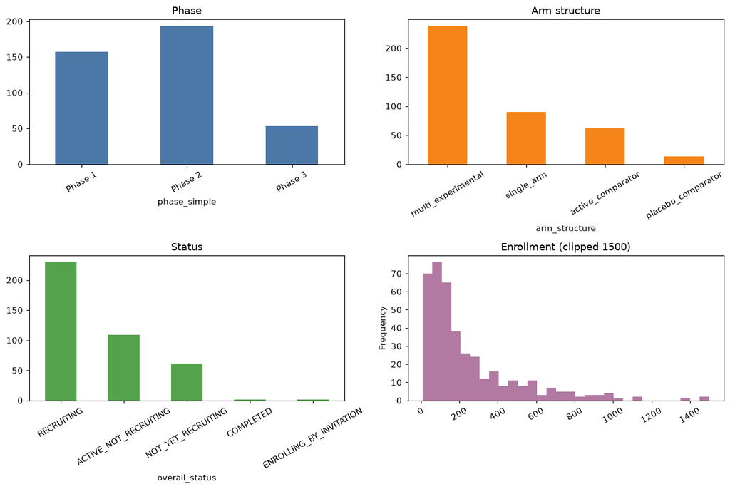

```
Industry-led: 403 | Big pharma involved: 107
TME-relevant modality: 224 | Biomarker-selected eligibility: 193
```

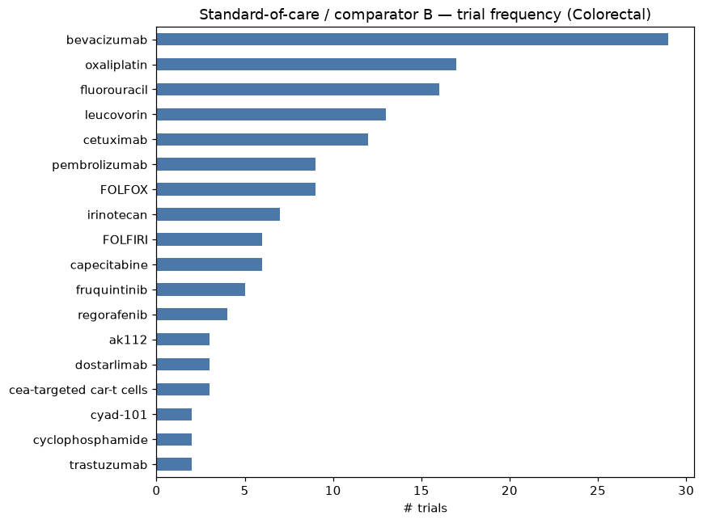

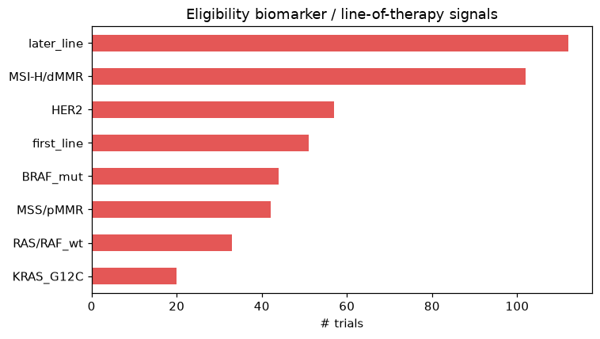

## 1-B. 표준치료(SoC) 대조군 코호트 분류 (정규화 보정 포함)

```
cohort_class
novel drug only (no SoC)        277
SoC-anchored                    108
non-drug (surgery/device/dx)     18

SoC-anchored: 108 / 403
```

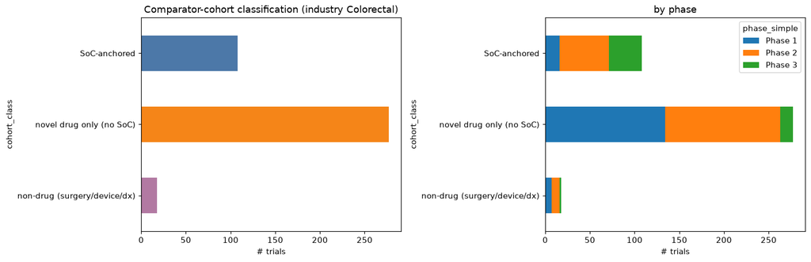

```
SoC-anchored 코호트의 치료 계열 분포:
soc_class
anti_VEGF;chemo                    24
chemo                              23
IO                                 16
anti_VEGF                          15
anti_EGFR;anti_VEGF;chemo           6
HER2                                5
SoC_generic                         5
anti_EGFR                           4
anti_EGFR;chemo                     4
IO;chemo                            3
SoC_generic;anti_EGFR;anti_VEGF     1
SoC_generic;anti_VEGF               1
```

## 2. Feature engineering — 표준치료 **성분(component)** 인코딩

**바이오마커·타겟·모달리티·arm 구조 등은 제외.** SoC-anchored 코호트만 남긴다. 군집화 feature는 표준치료를 **성분 약물 수준**으로 인코딩한다(FOLFOX→5FU+leucovorin+oxaliplatin). 이유: 레지멘을 원자 feature로 두면 "3개 중 2개만" 쓴 케이스나 유사 레지멘이 코사인 유사도 0으로 분리되지만, 성분으로 두면 **부분 겹침이 반영**돼 임상적으로 가까운 코호트가 가깝게 위치한다. 레지멘 라벨(`B_soc`)은 클러스터 해석·카드 표시용으로만 유지.

```
standard-of-care anchored cohorts: 108  (from 403 industry Colorectal trials)
feature matrix (SoC components): (108, 27)
성분 feature: ['B=atezolizumab', 'B=bevacizumab', 'B=capecitabine', 'B=carboplatin', 'B=cetuximab', 'B=cisplatin', 'B=dostarlimab', 'B=durvalumab', 'B=fluorouracil', 'B=fruquintinib', 'B=ipilimumab', 'B=irinotecan', 'B=leucovorin', 'B=nivolumab', 'B=oxaliplatin', 'B=paclitaxel', 'B=panitumumab', 'B=pe…
```

## 2-B. 레지멘 수준 데이터 (별도 표시)

군집은 성분 기반이지만, 사람이 읽기 좋은 **레지멘 관점**으로도 따로 집계한다: 각 코호트의 **화학요법 backbone**과 **추가 표적·면역 약물**(+anti-VEGF/+anti-EGFR/+IO/+HER2/+CLDN18.2)을 조합해 분포를 본다.

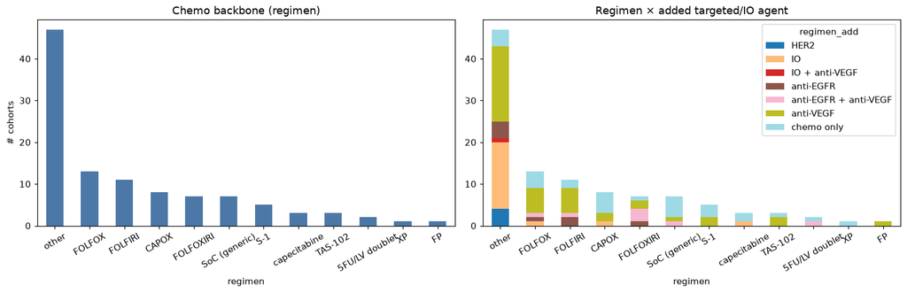

```
레지멘 × 추가약물 교차표:
regimen_add     HER2  IO  IO + anti-VEGF  anti-EGFR  anti-EGFR + anti-VEGF  anti-VEGF  chemo only
regimen
5FU/LV doublet     0   0               0          0                      1          0           1
CAPOX              0   1               0          0                      0          2           5
FOLFIRI            0   0               0          2                      1          6           2
FOLFOX             0   1               0          1                      1          6           4
FOLFOXIRI          0   0               0          1                      3          2           1
FP                 0   0               0          0                      0          1           0
S-1                0   0               0          0                      0          2           3
SoC (generic)      0   0               0          0                      1          1           5
TAS-102            0   0               0          0                      0          2           1
XP                 0   0               0          0                      0          0           1
capecitabine       0   1               0          0                      0          0           2
other              4  16               1          4                      0         18           4
```

## 3. 차원축소 & 군집화 — 치료구성 cosine 공간에서 KMeans (silhouette로 k 선택)

```
k=4  silhouette=0.309  sizes=[np.int64(41), np.int64(38), np.int64(19), np.int64(10)]
k=5  silhouette=0.336  sizes=[np.int64(38), np.int64(37), np.int64(18), np.int64(10), np.int64(5)]
k=6  silhouette=0.361  sizes=[np.int64(38), np.int64(29), np.int64(17), np.int64(10), np.int64(10), np.int64(4)]
k=7  silhouette=0.376  sizes=[np.int64(35), np.int64(24), np.int64(16), np.int64(13), np.int64(10), np.int64(6), np.int64(4)]
k=8  silhouette=0.433  sizes=[np.int64(38), np.int64(15), np.int64(12), np.int64(12), np.int64(10), np.int64(10), np.int64(7), np.int64(4)]
k=9  silhouette=0.465  sizes=[np.int64(38), np.int64(17), np.int64(15), np.int64(10), np.int64(10), np.int64(6), np.int64(5), np.int64(4), np.int64(3)]
chosen k = 9
```

## 4. 클러스터 프로파일링 — 아키타입 명명

|  | cluster | n | top_B | top_target | top_modality | phase_mix | bigpharma | biomarker_sel% |
| --- | --- | --- | --- | --- | --- | --- | --- | --- |
| 0 | 0 | 38 | bevacizumab, FOLFOX, FOLFIRI | VEGF/VEGFR, PD-1, EGFR | Monoclonal Antibody, Small Molecule, Bispecifi... | Phase 3:17, Phase 2:16, Phase 1:5 | 17 | 76 |
| 1 | 1 | 10 | pembrolizumab | PD-1, IL-2, BRAF | Monoclonal Antibody, Cell Therapy, Small Molecule | Phase 2:9, Phase 1:1 | 7 | 60 |
| 2 | 2 | 17 | bevacizumab, standard_of_care, trifluridine/ti... | PD-1, VEGF/VEGFR, Neoantigens | Monoclonal Antibody, Small Molecule, ADC | Phase 2:8, Phase 3:6, Phase 1:3 | 7 | 59 |
| 3 | 3 | 15 | trastuzumab, s-1, tucatinib | HER2, 5T4, PD-L1 | Small Molecule, Monoclonal Antibody, ADC | Phase 2:6, Phase 1:5, Phase 3:4 | 6 | 87 |
| 4 | 4 | 4 | cetuximab | EGFR, KRAS | Monoclonal Antibody, Small Molecule | Phase 2:2, Phase 1:1, Phase 3:1 | 1 | 50 |
| 5 | 5 | 10 | CAPOX, capecitabine, bevacizumab | PD-1, PD-L1, VEGF/VEGFR | Monoclonal Antibody, Small Molecule, Bispecifi... | Phase 2:6, Phase 3:3, Phase 1:1 | 2 | 60 |
| 6 | 6 | 5 | standard_of_care | PD-1, VEGF/VEGFR, MET | Monoclonal Antibody, ADC | Phase 2:3, Phase 3:2 | 1 | 80 |
| 7 | 7 | 3 | dostarlimab | PD-1 | Monoclonal Antibody | Phase 2:2, Phase 3:1 | 3 | 100 |
| 8 | 8 | 6 | fruquintinib, regorafenib, trifluridine/tipiracil | HER2, PD-1, VEGF/VEGFR | Monoclonal Antibody, ADC, Small Molecule | Phase 3:3, Phase 2:3 | 0 | 83 |

## 5. 코호트 유사도 2D 맵 — 클러스터 · Phase · 빅파마 강조

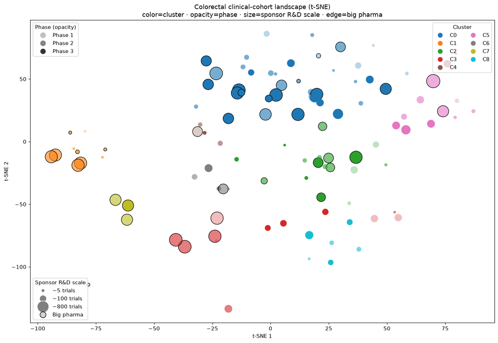

## 5-B. 클러스터별 대표 빅파마 코호트

각 클러스터의 중심(군집 특성공간)에서 **가장 가까운 빅파마 코호트**를 대표로 뽑아 코호트 정의를 정리한다. 대표 제약사·대조군 치료(B)·바이오마커와, 그 클러스터에 함께 속한 다른 제약사들을 표로.

```
saved outputs/cluster_representatives_crc.csv
```

|  | cluster | n | 대표 제약사 | 대조군 치료 B | 바이오마커 | phase | 대표 NCT | 다른 제약사 |
| --- | --- | --- | --- | --- | --- | --- | --- | --- |
| 0 | 0 | 38 | Cardiff Oncology | FOLFIRI;FOLFOX;bevacizumab | MSI-H/dMMR | Phase 2 | NCT06106308 | Bristol-Myers Squibb, MedImmune LLC, BioEclipse Therapeu... |
| 1 | 1 | 10 | Merck Sharp & Dohme LLC | pembrolizumab | MSI-H/dMMR | Phase 2 | NCT02628067 | Medicenna Therapeutics, Inc., Pfizer, Valo Therapeutics ... |
| 2 | 2 | 17 | AbbVie | bevacizumab | MSI-H/dMMR, BRAF_mut | Phase 2 | NCT06107413 | Seattle Project Corporation, BeiGene, Shanghai Kechow Ph... |
| 3 | 3 | 15 | Seagen, a wholly owned subsidiary of Pfizer | trastuzumab;tucatinib | HER2 | Phase 2 | NCT04430738 | NeoTX Therapeutics Ltd., AstraZeneca, Pfizer, Exelixis, ... |
| 4 | 4 | 4 | Bayer | cetuximab | - | Phase 1 | NCT07535112 | Allist Pharmaceuticals, Inc., Taizhou Mabtech Pharmaceut... |
| 5 | 5 | 10 | GlaxoSmithKline | CAPOX | MSI-H/dMMR, MSS/pMMR | Phase 2 | NCT06567782 | Chia Tai Tianqing Pharmaceutical Group Co., Ltd., Hoffma... |
| 6 | 6 | 5 | AbbVie | standard_of_care | - | Phase 2 | NCT07023289 | Agenus Inc., Taizhou Hanzhong biomedical co. LTD, Brenus... |
| 7 | 7 | 3 | GlaxoSmithKline | dostarlimab | MSI-H/dMMR | Phase 2 | NCT05723562 | - |
| 8 | 8 | 6 | Chipscreen Biosciences, Ltd. (빅파마 없음·최근접) | fruquintinib | MSS/pMMR | Phase 3 | NCT06497985 | Criterium, Inc., Kahr Bio Australia Pty Ltd, Shanghai JM... |

## 5-C. 인터랙티브 코호트 대시보드 (HTML)

`outputs/cohort_map_<slug>.html` — 좌: 코호트 맵, 우: ① 클러스터별 정보, ② **R&D 규모순 제약사 드롭다운** → 선택 시 맵에서 위치 하이라이트 + 그 제약사 임상의 ClinicalTrials.gov 링크·상세 카드. 맵의 점 클릭·hover(제약사·레지멘·Phase·status)도 지원.

```
saved /Users/minsung.choi/clinical_data_finder/outputs/cohort_map_crc.html
```

## 6. 가치 랭킹 — 표준치료 B 데이터 자산 (수요 폭 중심)

각 B에 대해: **demand_breadth**(그 B를 쓰는 진행 중 트라이얼 수, 주축) + 스폰서 다양성 + 빅파마 수 + phase 가중 + 등록 규모 + TME 관련성 + 바이오마커 개방성.

|  | B (standard therapy) | demand_breadth | sponsors | bigpharma | phase_weight | n_phase3 | enroll_sum | tme_rel% | biomarker% | value_score |
| --- | --- | --- | --- | --- | --- | --- | --- | --- | --- | --- |
| 0 | bevacizumab | 40 | 37 | 16 | 88.8 | 19 | 14909 | 82 | 65 | 0.980500 |
| 1 | FOLFOX | 20 | 19 | 8 | 42.8 | 9 | 6511 | 80 | 75 | 0.530586 |
| 2 | cetuximab | 14 | 12 | 9 | 34.4 | 9 | 5960 | 71 | 79 | 0.420757 |
| 3 | FOLFIRI | 11 | 11 | 6 | 24.0 | 5 | 4192 | 73 | 91 | 0.342935 |
| 4 | pembrolizumab | 11 | 9 | 8 | 16.4 | 0 | 2734 | 73 | 64 | 0.324522 |
| 5 | FOLFOXIRI | 7 | 6 | 5 | 18.2 | 5 | 3584 | 100 | 86 | 0.268463 |
| 6 | CAPOX | 8 | 6 | 2 | 17.8 | 4 | 2709 | 100 | 75 | 0.250289 |
| 7 | standard_of_care | 7 | 7 | 2 | 15.4 | 3 | 1851 | 71 | 86 | 0.222877 |
| 8 | fruquintinib | 6 | 6 | 0 | 13.8 | 3 | 1013 | 83 | 83 | 0.186776 |
| 9 | trifluridine/tipiracil | 5 | 5 | 1 | 13.0 | 4 | 1782 | 100 | 60 | 0.185950 |
| 10 | capecitabine | 6 | 6 | 1 | 11.8 | 2 | 994 | 83 | 50 | 0.181115 |
| 11 | fluorouracil | 5 | 5 | 2 | 8.8 | 1 | 1357 | 80 | 40 | 0.167599 |
| 12 | trastuzumab | 4 | 3 | 3 | 5.8 | 0 | 894 | 75 | 100 | 0.160515 |
| 13 | regorafenib | 4 | 3 | 0 | 12.0 | 4 | 1406 | 75 | 100 | 0.153208 |
| 14 | s-1 | 5 | 4 | 0 | 7.6 | 1 | 1336 | 40 | 80 | 0.138422 |

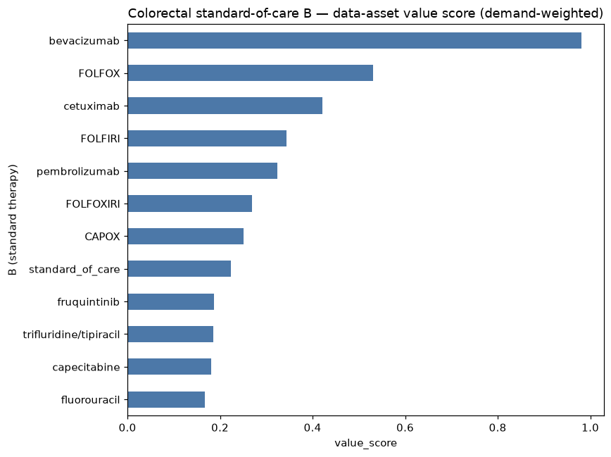

## 7. 먼저 접근할 코호트 — 빅파마 참여 + Phase 3 우선

|  | nct_id | phase_simple | lead_sponsor | B_soc | targets | enrollment | arm_structure | biomarker_selected |
| --- | --- | --- | --- | --- | --- | --- | --- | --- |
| 90 | NCT07620574 | Phase 3 | Exelixis | atezolizumab;nivolumab | MET | 5000 | single_arm | 0 |
| 88 | NCT07549412 | Phase 3 | EMD Serono Research & Development Institute, Inc. | bevacizumab;trifluridine/tipiracil | VEGF/VEGFR | 1020 | active_comparator | 0 |
| 51 | NCT06662786 | Phase 3 | Janssen Research & Development, LLC | FOLFOXIRI;cetuximab | EGFR | 1000 | active_comparator | 1 |
| 70 | NCT07221357 | Phase 3 | Bristol-Myers Squibb | FOLFIRI;FOLFOX | VEGF/VEGFR | 990 | multi_experimental | 1 |
| 84 | NCT07525206 | Phase 3 | AbbVie | bevacizumab | VEGF/VEGFR | 990 | multi_experimental | 0 |
| 95 | NCT07702032 | Phase 3 | Genmab | FOLFIRI;FOLFOX;cetuximab | EGFR | 960 | active_comparator | 1 |
| 34 | NCT05855200 | Phase 3 | GlaxoSmithKline | CAPOX;FOLFOX | PD-1 | 892 | active_comparator | 1 |
| 3 | NCT04008030 | Phase 3 | Bristol-Myers Squibb | FOLFOXIRI;bevacizumab;cetuximab | CTLA-4 | 839 | active_comparator | 1 |
| 71 | NCT07222800 | Phase 3 | Pfizer | bevacizumab | PD-1 | 800 | active_comparator | 1 |
| 53 | NCT06750094 | Phase 3 | Janssen Research & Development, LLC | FOLFIRI;bevacizumab;cetuximab | VEGF/VEGFR | 700 | active_comparator | 1 |
| 100 | NCT07775287 | Phase 3 | Genmab | FOLFOXIRI;bevacizumab;cetuximab | VEGF/VEGFR | 600 | active_comparator | 1 |
| 65 | NCT06997497 | Phase 3 | Merck Sharp & Dohme LLC | FOLFOX;bevacizumab | VEGF/VEGFR | 477 | active_comparator | 1 |
| 40 | NCT06252649 | Phase 3 | Amgen | FOLFIRI;bevacizumab | VEGF/VEGFR | 450 | active_comparator | 0 |
| 21 | NCT05253651 | Phase 3 | Seagen, a wholly owned subsidiary of Pfizer | FOLFOX;bevacizumab;cetuximab | HER2 | 400 | active_comparator | 1 |
| 20 | NCT05239741 | Phase 3 | Merck Sharp & Dohme LLC | FOLFOXIRI;bevacizumab;cetuximab | PD-1 | 100 | active_comparator | 1 |
| 98 | NCT07740720 | Phase 3 | GlaxoSmithKline | dostarlimab | PD-1 | 90 | single_arm | 1 |
| 0 | NCT02628067 | Phase 2 | Merck Sharp & Dohme LLC | pembrolizumab | PD-1 | 1609 | multi_experimental | 1 |
| 68 | NCT07079631 | Phase 2 | BioNTech SE | bevacizumab;standard_of_care | NaN | 482 | active_comparator | 1 |
| 8 | NCT04482309 | Phase 2 | AstraZeneca | trastuzumab;trastuzumab deruxtecan | HER2 | 477 | multi_experimental | 1 |
| 55 | NCT06820463 | Phase 2 | AbbVie | fluorouracil;leucovorin | VEGF/VEGFR | 390 | multi_experimental | 0 |

## 8. 요약

- **가치 랭킹(`outputs/value_ranking_crc.csv`)**: 대장암(Colorectal)에서 TME 데이터를 만들면 가장 많은 스폰서가 원할 표준치료 B 순위.
- **코호트 맵/대시보드(`outputs/cohort_map_crc.png` / `.html`)**: 제약사들이 집중하는 코호트 아키타입 분포, Phase·빅파마 강조.
- **먼저 접근할 코호트**: 빅파마 참여 + Phase 3 pivotal 우선.